# Tunnel diode 2024

YDS

2024-06-10

# Введение

Туннельные диоды были открыты учёным Эсаки и используют эффект квантового туннелирования электронов через потенциальный барьер.

Этот эффект связан с волновой природой электронов, благодаря которой они могут попадать в классически запрещённые области.

Существует несколько видов туннельных диодов. Наиболее типичные сделаны на основе PN-переходов (рис. 1), но есть и другие (например, резонансно-туннельные диоды, диоды на основе свехрешёток и т.д.)

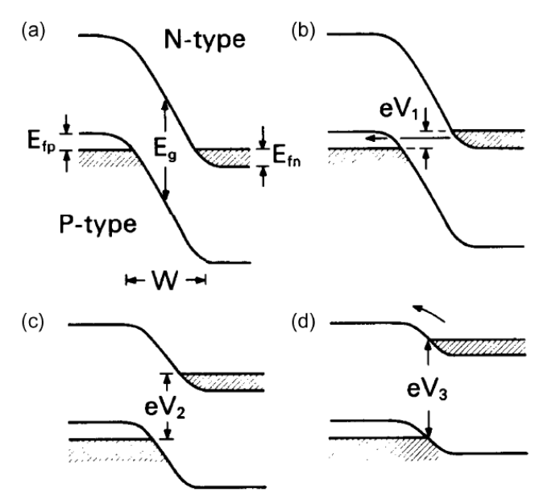

Рисунок 1. Схема туннельного диода Эсаки [1].

Туннельные диоды известны тем, что на их ВАХ наблюдается область отрицательного дифференциального сопротивления (отрицательной дифференциальной проводимости — ОДП). Дифференциальная проводимость определяется как:

$$\Omega_{d}=\frac{dI}{dV}$$
Обычная проводимость — отношение тока к напряжению — не может быть отрицательной, а дифференциальная может. При этом ток положительный, но начинает падать при росте напряжения. Это можно видеть на рис. 2.

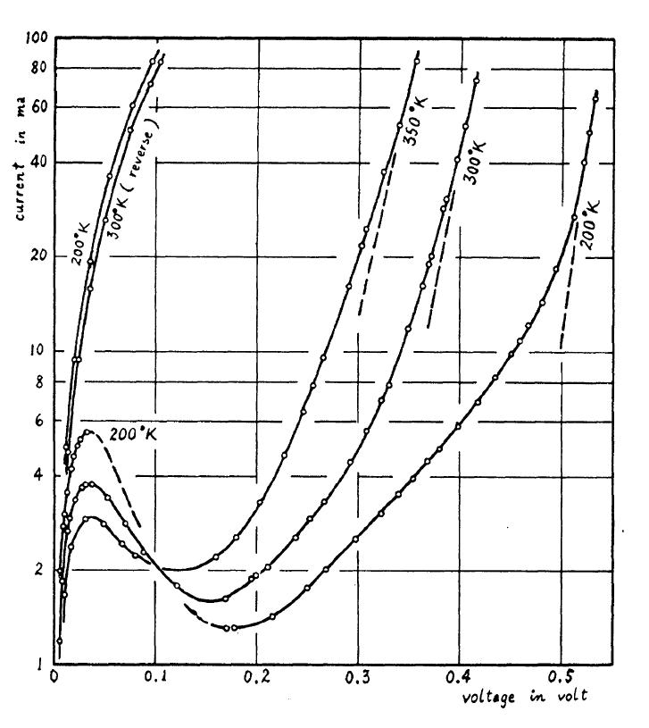

Рисунок 2. ВАХ туннельного диода [1].

Участок ОДП может быть использован для генераторов переменного тока (генераторов колебаний), потому что он позволяет компенсировать внутреннее сопротивление цепи и избежать затухания колебаний.

# Обзор литературы

Ток через туннельный диод можно рассчитать по формуле Эсаки [2].

$$I(V)=\frac{em_{e}kT}{2\pi^{2}\hbar^{3}}\int_{0}^{\infty}T_{c}\left(E_{\perp}\right)\left[\ln\left(1+\exp\frac{E_{Fn}+eV-E_{\perp}}{kT}\right)-\ln\left(1+\exp\frac{E_{Fp}-E_{\perp}}{kT}\right)\right]\mathrm{d}E_{\perp}
\tag{1}$$

Где $T_c$ — вероятность (коэффициент) прохождения электронов через барьер, $E_{\perp}$ — кинетическая энергия электронов в направлении границы между P и N областями, которая отсчитывается от дна зоны проводимости $E_c$.

Логарифмы описывают распределение электронов по энергиям в P и N областях.

Для работы туннельного диода области N и P должны быть сильно легированы, то там должно быть очень много примесей. Тогда при $V=0$ уровни Ферми будут находится внутри зоны проводимости в N области и внутри валентной зоны в P области, как изображено на рис. 3а.

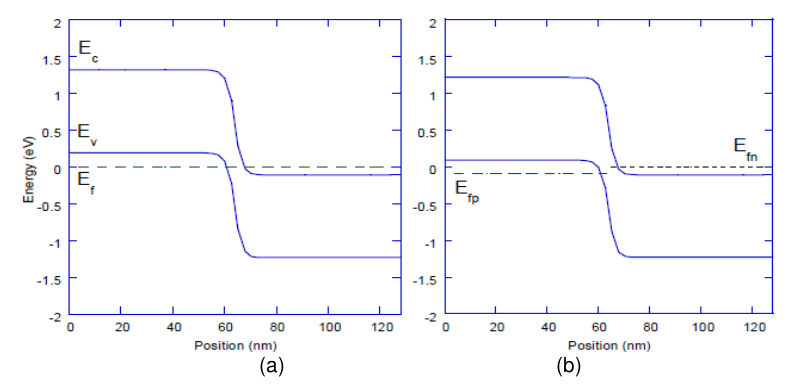

Рисунок 3. Зонная структура туннельного диода при а) $V=0$ и b) $V>0$ [3].

Вероятность прохождения барьера может быть рассчитана с помощью квантовой механики для барьеров любой формы. В данном случае барьер похож на треугольный (рис. 4), но можно его считать и прямоугольным. При повышении напряжения уровни Ферми будут смещаться друг относительно друга и барьер между P и N областями будет уменьшаться (рис. 3b).

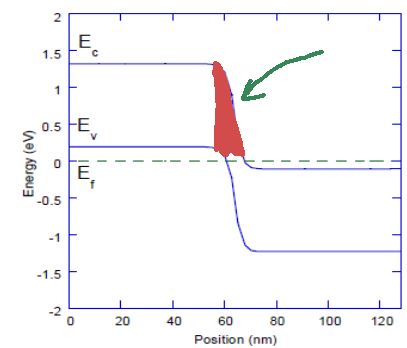

Рисунок 4. Энергетический барьер.

Самый простой вид имеет коэффициент прохождения для очень узкого барьера в виде дельта-функции:

$$U(x)=\alpha \delta(x),\qquad \alpha = Ha
\tag{2}$$

где $H$ — высота барьера в единицах энергии (эВ), а $a$ — ширина барьера (например, в нм).

Для неё вероятность прохождения имеет вид:

$$T_c(E)=\frac{E}{E+\frac{m_e
\alpha^2}{2\hbar^2}} \tag{3}$$

# Основные формулы

## Константы

| Обозначение | Формула | Переменная | Значение | Единицы |
| --- | --- | --- | --- | --- |
| $k$ | $k$ | k_boltzmann | 8.62e-5 | эВ$\cdot$K$^{-1}$ |
| $q$ | $\displaystyle \frac{e}{\hbar}$ | e_h | 2.43e-4 | А$\cdot$эВ$^{-1}$ |
| $K$ | $\displaystyle \frac{\hbar^2}{m_0}$ | h2_m0 | 0.0762 | эВ$\cdot$нм$^2$ |
| $C$ | $\displaystyle \frac{e^2}{4\pi \varepsilon_0}$ | e2_4pieps0 | 1.44 | эВ$\cdot$нм |

## Исходные параметры

| Величина | Обозначение | Переменная | Диапазон | Значение | Единицы |
| --- | --- | --- | --- | --- | --- |
| Ширина запр. зоны | $E_g$ | band_gap | 0.2 – 2 | 1.12 | эВ |
| Эфф. масса эл. | $m_e$ | eff_mass_e | 0.01 – 1 | 0.19 | $m_0$ |
| Эфф. масса дыр. | $m_h$ | eff_mass_h | 0.01 – 1 | 0.49 | $m_0$ |
| Диэлектр. прониц. | $\varepsilon$ | dielectric_eps | 1 – 15 | 11.7 | - |
| Температура | $T$ | temperature | 4 – 400 | 300 | К |
| Конц. доноров | $N_d$ | donor_conc | 1e-4 – 0.1 | 0.1 | нм$^{-3}$ |
| Конц. акцепторов | $N_a$ | accept_conc | 1e-4 – 0.1 | 0.1 | нм$^{-3}$ |
| Минимальное напряжение | $V_{min}$ | voltage_min | -2 – 0 | -0.5 | В |
| Максимальное напряжение | $V_{max}$ | voltage_max | 0 – 5 | 2 | В |

Примечание: т.к. напряжение указываетс в волтах, а энергия — в электрон-вольтах, везде где в формулах присутствует $eV$ можно использовать просто $v$, на заряд электрона умножать не нужно.

## Вторичные параметры

| Обозначение | Формула | Переменная | Единицы |
| --- | --- | --- | --- |
| $N_c$ | $\displaystyle 2 \cdot \left( \frac{m_e kT}{2\pi K} \right)^{3/2}$ | n_c | нм$^{-3}$ |
| $N_v$ | $\displaystyle 2 \cdot \left( \frac{m_h kT}{2\pi K} \right)^{3/2}$ | n_v | нм$^{-3}$ |
| $E_{Fn}-E_c$ | $\displaystyle kT \ln \left( \frac{N_d}{N_c} \right)$ | fermi_n | эВ |
| $E_{Fp}-E_v$ | $\displaystyle kT \ln \left( \frac{N_v}{N_a} \right)$ | fermi_p | эВ |
| $\Delta \Phi$ | $\displaystyle E_{Fn} - E_c -\left(E_{Fp} - E_v \right) +E_g$ | delta_phi | эВ |
| $W^3$ | $\displaystyle \frac{\pi C K k T}{m_e \varepsilon} \frac{N_a N_d}{N_a+N_d}$ | transmission_parameter | эВ$^3$ |
| $A$ | $\displaystyle \frac{q m_e k^{2}T^{2}}{2\pi^2K}$ | richardson_constant | A$\cdot$нм$^{-2}$ |
| $w_{0}$ | $\displaystyle \exp\frac{E_{Fn}-E_{c}}{kT}$ | w_0 | - |
| $s_{0}$ | $\displaystyle \exp\frac{E_{Fn}-E_{c}-\Delta\Phi}{kT}$ | s_0 | - |

### Пояснение параметров

$$2 \cdot \left( \frac{m_e m_0 kT}{2\pi
\hbar^2} \right)^{3/2} = 2 \cdot \left( \frac{m_e kT}{2\pi K}
\right)^{3/2}$$

$$2 \cdot \left( \frac{m_h m_0 kT}{2\pi
\hbar^2} \right)^{3/2} = 2 \cdot \left( \frac{m_h kT}{2\pi K}
\right)^{3/2}$$

$$E_{Fn}-E_{Fp} = E_{Fn} - E_c
-\left(E_{Fp} - E_v \right) +E_c-E_v= E_{Fn} - E_c -\left(E_{Fp} - E_v
\right) +E_g$$

$$W^3 =
\frac{e^{2}}{4\varepsilon_{0}\varepsilon}\frac{\hbar^{2}kT}{m_{e}}\frac{N_{a}N_{d}}{N_{a}+N_{d}}
\tag{4}$$

$$A = \frac{1}{2\pi^2} \frac{e}{\hbar}
\frac{m_e k^{2}T^{2}}{\hbar^2} = \frac{q m_e k^{2}T^{2}}{2\pi^2K}
\tag{5}$$

## Окончательные формулы

### Общий ток

$$I\left(V\right)=I_{1}\left(V\right)+I_{2}\left(V\right)
\tag{6}$$

### Туннельный ток

$$I_{1}\left(V\right)=A\int_{a}^{b}\frac{u\ln\left(1+w_{0}e^{-u}\right)}{u+\left(\Delta\Phi-eV\right)^{3}/W^{3}}du
\tag{7}$$

### Диодный ток

$$I_{2}\left(V\right)=A\cdot
s_{0}\left[\exp\left(\frac{eV}{kT}\right)-1\right] \tag{8}$$

### Пределы интегрирования

Нижний предел определяется нижней границей, где ещё есть дырки (пустые места) в валентной зоне p-области, чтобы туда могли туннелировать электроны.

$$a=\frac{\Delta\Phi-E_{g}-|E_{Fp}-E_v|-5kT-eV}{kT}>0\qquad
\tag{9}$$
$$a = 0, \qquad eV >
\Delta\Phi-E_{g}-|E_{Fp}-E_v|-5kT$$
Нижний предел тока должен быть $a \geq 0$, поэтому если выражение (9) даёт отрицательную величину, мы приравниваем его к нулю. $5kT$ выбрано из-за характерной формы распределения Ферми, которое на этом расстоянии от уровня Ферми спадает почти до нуля.

Верхний предел определяется границей валентной зоны p-области, потому что в запрещённую зону электроны туннелировать не могут.

$$b=\frac{\Delta\Phi-E_{g}-eV}{kT}>0,\qquad
eV<\Delta\Phi-E_{g} \tag{10}$$
$$b=0, \qquad eV \geq \Delta\Phi-E_{g}$$

Верхний предел интегрирования туннельного тока станет равным нулю для предельного значения напряжения, после которого туннелирование полностью прекратится. После этого надо учитывать только диодный ток.

# Литература

1. Leo Esaki. Long Journey into Tunneling. Science, 22 March 1974, Volume 183, Number 4130.
2. N. Moulin, Mohamed Amara, F. Mandorlo, M. Lemiti. Tunnel junction I ( V ) characteristics: Review and a new model for p-n homojunctions. Journal of Applied Physics, 2019, 126 (3), pp.033105. 10.1063/1.5104314. hal-03035269
3. Messaadi Lotfi and Dibi Zohir. A Spice Behavioral Model of Tunnel Diode: Simulation and Application. International Journal of Control and Automation Vol. 9, No. 4 (2016), pp. 39-50 http://dx.doi.org/10.14257/ijca.2016.9.4.05
4. D. Mtn, M. PATIL, J. CHEN. Solid-State ElectronicsVol. 32, No. 1I, pp. 1025-1031, 1989